# intro_statistics_D2

Nasimeh

2022-09-27

#For loop For(what we want to loop over){ }

Example: For(b in 1:5){ #for each bear one to five function() #function=drink it }

for (b in 1:5){ print(b) #prints one two three four five }

```r
for(b in 1:5) {
  print(b)
}
```

```
## [1] 1
## [1] 2
## [1] 3
## [1] 4
## [1] 5
```

Subsetting in for loop#1

```r
s <- c("e","g","n","f","a")

for (indiancurry in s) {
  print(indiancurry)        #When print within the loop prints all the elements in s
}
```

```
## [1] "e"
## [1] "g"
## [1] "n"
## [1] "f"
## [1] "a"
```

```r
for (indiancurry in s) {

}
  print(indiancurry)        #because it loops over the "indiancurry" and gives the last element of s
```

```
## [1] "a"
```

[] is for indexing subsetting#2

```r
for (b in 1:5){
  print(s[b])
}
```

```
## [1] "e"
## [1] "g"
## [1] "n"
## [1] "f"
## [1] "a"
```

```r
#can as well subset using
s[3]
```

```
## [1] "n"
```

# Today we learn about character and factor variables and data

statistical inference for data scinece (book) - read section for ggplot!

#Working with data (part1) Every square has one length in the datafram dataframe has two dimension (rows and columns) - syntax for indexing df[rows, columns] lenght = number of observation

##Loading data in R working directory = where our files are setwd = set working directory getwd = checking the current working directory relative path = data() = load existing data in r to environment

[output not shown]

```r
data("iris")

saveRDS(iris, "testdata.RDS")    #RDS is binary (0,1)
```

Cleaning workspace

ls = retunr the name on the objects in the environment character 0 = not defined

```r
rm(list = ls())       #removes objects in the global environment
```

CSV data fromat = seperated values (comma, semicolon, tab-delimited input files) - most proporal data format - every row on the data ends with new line - first row column names function is: read.csv() - can read files directly from online when provided URL link - first row is treated differently - first row a character (because it could be numeric etc…) - write.csv = can write csv files > creating a csv file

```r
#write csv files
write.csv(iris, file = "iristest.CSV")
```

Unlink = deleted the files specified by X - X = vector or directoried to be deleted

```r
unlink("iristest.CSV")
```

When downloading online: steps: - url - download file - unzip - read the data

```r
data("airquality")
dim(airquality)
```

```
## [1] 153   6
```

```r
str(airquality)                   #structure of the data - info(characteristics of the ) about data frame
```

```
## 'data.frame':    153 obs. of  6 variables:
##  $ Ozone  : int  41 36 12 18 NA 28 23 19 8 NA ...
##  $ Solar.R: int  190 118 149 313 NA NA 299 99 19 194 ...
##  $ Wind   : num  7.4 8 12.6 11.5 14.3 14.9 8.6 13.8 20.1 8.6 ...
##  $ Temp   : int  67 72 74 62 56 66 65 59 61 69 ...
##  $ Month  : int  5 5 5 5 5 5 5 5 5 5 ...
##  $ Day    : int  1 2 3 4 5 6 7 8 9 10 ...
```

Subsetting:

if we want to from two columns we can: -c(Temp, Ozone)

```r
subset(airquality, Temp > 80, select = c(Ozone, Temp))  #select = selecting columns from data set #gives columns if temperature above 80
```

```
##     Ozone Temp
## 29     45   81
## 35     NA   84
## 36     NA   85
## 38     29   82
## 39     NA   87
## 40     71   90
## 41     39   87
## 42     NA   93
## 43     NA   92
## 44     23   82
## 61     NA   83
## 62    135   84
## 63     49   85
## 64     32   81
```

[output cut: 54 more lines]

```r
subset(airquality, Day == 1, select = -Temp)   # -Temp = removing /dropping the Temp from data set
```

```
##     Ozone Solar.R Wind Month Day
## 1      41     190  7.4     5   1
## 32     NA     286  8.6     6   1
## 62    135     269  4.1     7   1
## 93     39      83  6.9     8   1
## 124    96     167  6.9     9   1
```

```r
subset(airquality, select = Ozone:Wind)   # Ozone:Wind = columns from Ozone to Wind
```

```
##     Ozone Solar.R Wind
## 1      41     190  7.4
## 2      36     118  8.0
## 3      12     149 12.6
## 4      18     313 11.5
## 5      NA      NA 14.3
## 6      28      NA 14.9
## 7      23     299  8.6
## 8      19      99 13.8
## 9       8      19 20.1
## 10     NA     194  8.6
## 11      7      NA  6.9
## 12     16     256  9.7
## 13     11     290  9.2
## 14     14     274 10.9
```

[output cut: 139 more lines]

colnames() rownames ()

```r
colnames(airquality)           #gives the name of the columnames
```

```
## [1] "Ozone"   "Solar.R" "Wind"    "Temp"    "Month"   "Day"
```

:: = using this syntax that we want from this backage readstata13::read.dta13

```r
library(readstata13)
library(foreign)
library(haven)
```

Reading stata dataset: use.value.lables = should I create a nominal values? factors is nominall/categorical value

readstata13 (function is read.dta13) = convert-factors > trying to deal with lable of the value - should they be a factors or not str () to check if variables are factors > gives more information is.factors () = to check if variable is a factor or not

readin excel sheet: readxl = what rows and columns you want to read or read the whole sheet - path = file

```r
is.factor(airquality)
```

```
## [1] FALSE
```

```r
str(airquality)
```

```
## 'data.frame':    153 obs. of  6 variables:
##  $ Ozone  : int  41 36 12 18 NA 28 23 19 8 NA ...
##  $ Solar.R: int  190 118 149 313 NA NA 299 99 19 194 ...
##  $ Wind   : num  7.4 8 12.6 11.5 14.3 14.9 8.6 13.8 20.1 8.6 ...
##  $ Temp   : int  67 72 74 62 56 66 65 59 61 69 ...
##  $ Month  : int  5 5 5 5 5 5 5 5 5 5 ...
##  $ Day    : int  1 2 3 4 5 6 7 8 9 10 ...
```

```r
str(airquality$Temp)
```

```
##  int [1:153] 67 72 74 62 56 66 65 59 61 69 ...
```

```r
library(readxl)
#df <- readxl::read_excel()

readxl_example()
```

```
##  [1] "clippy.xls"    "clippy.xlsx"   "datasets.xls"  "datasets.xlsx"
##  [5] "deaths.xls"    "deaths.xlsx"   "geometry.xls"  "geometry.xlsx"
##  [9] "type-me.xls"   "type-me.xlsx"
```

```r
readxl_example("clippy.xls")
```

```
## [1] "/Library/Frameworks/R.framework/Versions/4.2/Resources/library/readxl/extdata/clippy.xls"
```

```r
xls_example <- readxl_example("datasets.xls")
read_excel(xls_example)
```

```
## # A tibble: 150 × 5
##    Sepal.Length Sepal.Width Petal.Length Petal.Width Species
##           <dbl>       <dbl>        <dbl>       <dbl> <chr>
##  1          5.1         3.5          1.4         0.2 setosa
##  2          4.9         3            1.4         0.2 setosa
##  3          4.7         3.2          1.3         0.2 setosa
##  4          4.6         3.1          1.5         0.2 setosa
##  5          5           3.6          1.4         0.2 setosa
##  6          5.4         3.9          1.7         0.4 setosa
##  7          4.6         3.4          1.4         0.3 setosa
##  8          5           3.4          1.5         0.2 setosa
##  9          4.4         2.9          1.4         0.2 setosa
## 10          4.9         3.1          1.5         0.1 setosa
## # … with 140 more rows
```

```r
read_excel(xls_example, range = cell_rows(1:3))
```

```
## # A tibble: 2 × 5
##   Sepal.Length Sepal.Width Petal.Length Petal.Width Species
##          <dbl>       <dbl>        <dbl>       <dbl> <chr>
## 1          5.1         3.5          1.4         0.2 setosa
## 2          4.9         3            1.4         0.2 setosa
```

summary() = NaN = not anumber NULL = not defined Inf = number

```r
colnames(attenu)
```

```
## [1] "event"   "mag"     "station" "dist"    "accel"
```

```r
vec <- colnames(attenu)
length(vec)
```

```
## [1] 5
```

```r
class(vec)
```

```
## [1] "character"
```

```r
vec[3]
```

```
## [1] "station"
```

```r
vec2 <- vec[3:1]
vec2
```

```
## [1] "station" "mag"     "event"
```

```r
summary(attenu, digits = 4)
```

```
##      event            mag           station         dist
##  Min.   : 1.00   Min.   :5.000   117    :  5   Min.   :  0.50
##  1st Qu.: 9.00   1st Qu.:5.300   1028   :  4   1st Qu.: 11.32
##  Median :18.00   Median :6.100   113    :  4   Median : 23.40
##  Mean   :14.74   Mean   :6.084   112    :  3   Mean   : 45.60
##  3rd Qu.:20.00   3rd Qu.:6.600   135    :  3   3rd Qu.: 47.55
##  Max.   :23.00   Max.   :7.700   (Other):147   Max.   :370.00
##                                  NA's   : 16
##      accel
##  Min.   :0.00300
##  1st Qu.:0.04425
##  Median :0.11300
##  Mean   :0.15422
##  3rd Qu.:0.21925
##  Max.   :0.81000
##
```

```r
                                  #is.na() checking missing values
is.na(attenu)                     #logical constant length 1 = vector of length 1 (1 value)
```

```
##        event   mag station  dist accel
##   [1,] FALSE FALSE   FALSE FALSE FALSE
##   [2,] FALSE FALSE   FALSE FALSE FALSE
##   [3,] FALSE FALSE   FALSE FALSE FALSE
##   [4,] FALSE FALSE   FALSE FALSE FALSE
##   [5,] FALSE FALSE   FALSE FALSE FALSE
##   [6,] FALSE FALSE   FALSE FALSE FALSE
##   [7,] FALSE FALSE   FALSE FALSE FALSE
##   [8,] FALSE FALSE   FALSE FALSE FALSE
##   [9,] FALSE FALSE   FALSE FALSE FALSE
##  [10,] FALSE FALSE   FALSE FALSE FALSE
##  [11,] FALSE FALSE   FALSE FALSE FALSE
##  [12,] FALSE FALSE   FALSE FALSE FALSE
##  [13,] FALSE FALSE   FALSE FALSE FALSE
##  [14,] FALSE FALSE   FALSE FALSE FALSE
```

[output cut: 168 more lines]

if loop: else (if not one condition then else) is.na () is.numeric ()

```r
if(is.numeric(attenu$event)){
  mean(attenu$event)
} else {                        #remeber to have it in the correct line to run it correctly
  str(attenu$event)
}
```

```
## [1] 14.74176
```

```r
if(is.numeric(iris$Species)){
  mean(iris$Species)
} else {
  str(iris$Species)
}
```

```
##  Factor w/ 3 levels "setosa","versicolor",..: 1 1 1 1 1 1 1 1 1 1 ...
```

```r
is.na(attenu$station)
```

```
##   [1] FALSE FALSE FALSE FALSE FALSE FALSE FALSE FALSE FALSE FALSE FALSE FALSE
##  [13] FALSE FALSE FALSE FALSE FALSE FALSE FALSE FALSE FALSE FALSE FALSE FALSE
##  [25] FALSE FALSE FALSE FALSE FALSE FALSE FALSE FALSE FALSE FALSE FALSE FALSE
##  [37] FALSE FALSE FALSE FALSE FALSE FALSE FALSE FALSE FALSE FALSE FALSE FALSE
##  [49] FALSE FALSE FALSE FALSE FALSE FALSE FALSE FALSE FALSE FALSE FALSE FALSE
##  [61] FALSE FALSE FALSE FALSE FALSE FALSE FALSE FALSE FALSE FALSE FALSE FALSE
##  [73] FALSE FALSE FALSE FALSE FALSE FALSE  TRUE FALSE  TRUE FALSE FALSE FALSE
##  [85] FALSE FALSE FALSE FALSE FALSE FALSE FALSE FALSE FALSE  TRUE FALSE  TRUE
##  [97] FALSE FALSE  TRUE FALSE FALSE FALSE FALSE FALSE FALSE FALSE  TRUE  TRUE
## [109] FALSE FALSE FALSE FALSE FALSE  TRUE FALSE  TRUE FALSE  TRUE FALSE FALSE
## [121] FALSE FALSE  TRUE FALSE FALSE  TRUE FALSE  TRUE FALSE FALSE FALSE FALSE
## [133] FALSE FALSE FALSE FALSE FALSE FALSE FALSE FALSE FALSE FALSE FALSE FALSE
## [145] FALSE FALSE FALSE FALSE FALSE FALSE FALSE FALSE FALSE FALSE  TRUE  TRUE
## [157] FALSE FALSE FALSE  TRUE FALSE FALSE FALSE FALSE FALSE FALSE FALSE FALSE
## [169] FALSE FALSE FALSE FALSE FALSE FALSE FALSE FALSE FALSE FALSE FALSE FALSE
## [181] FALSE FALSE
```

```r
length(is.na(attenu$station))   #how many onjects is defined in this obeservation
```

```
## [1] 182
```

```r
sum(is.na(attenu$station))      # we get 16 because FALSE and TRUE are assigned values (TRUE=1)
```

```
## [1] 16
```

Plot()

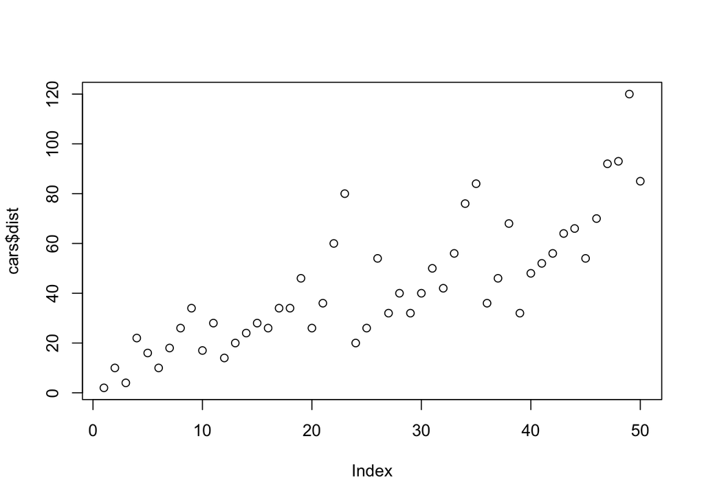

```r
plot(cars$dist)         #index is not telling anything, not good plot
```

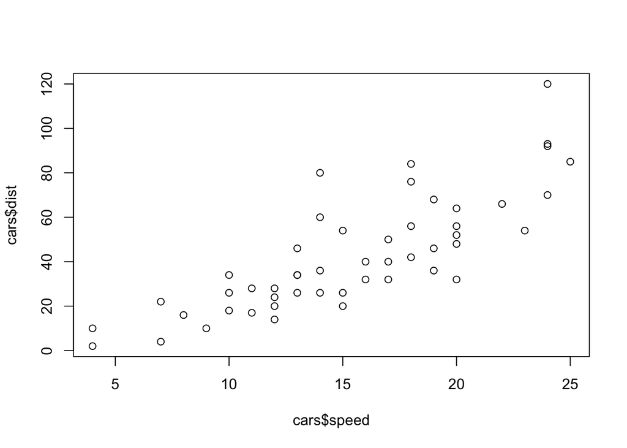

```r
plot(cars$speed, cars$dist)
```

#Character variables

paste() = if you given an object that is not a character will be converted to character = paste makes the object in one word - grammer in are as. - as.character () / is.character () = logical - - vector can only be numeric, logic.. can’t be blend

cat() paste0()

```r
paste("2", "koira")
```

```
## [1] "2 koira"
```

```r
vec <- cars$speed
is.character(vec)
```

```
## [1] FALSE
```

```r
vec
```

```
##  [1]  4  4  7  7  8  9 10 10 10 11 11 12 12 12 12 13 13 13 13 14 14 14 14 15 15
## [26] 15 16 16 17 17 17 18 18 18 18 19 19 19 20 20 20 20 20 22 23 24 24 24 24 25
```

```r
#print the observations
for (pasta in vec) {
  print(pasta)
}
```

```
## [1] 4
## [1] 4
## [1] 7
## [1] 7
## [1] 8
## [1] 9
## [1] 10
## [1] 10
## [1] 10
## [1] 11
## [1] 11
## [1] 12
## [1] 12
## [1] 12
## [1] 12
```

[output cut: 35 more lines]

```r
for (pasta in vec) {       # didn't return anything because inside of the loop we can't use paste
  paste(pasta)
}


#for (pasta in vec){
#  cat(pasta, " \")
#}      # you have to add end to line sign!
```

Substring() = strsplit() = split object (cooked tofu is one word in R) cooked tofu based on smth

```r
fn <- "tofu"

nchar(fn)
```

```
## [1] 4
```

```r
substr("cooked tofu", start = 1, stop = 2)
```

```
## [1] "co"
```

```r
substr("cooked tofu", start = 8, stop = 12)
```

```
## [1] "tofu"
```

```r
#automatically and not labor heavy: searching for keywords in R

strsplit(x="cooked tofu", split = " ")
```

```
## [[1]]
## [1] "cooked" "tofu"
```

which() = which one it’s true? getting the location of object in the vector

```r
state.name
```

```
##  [1] "Alabama"        "Alaska"         "Arizona"        "Arkansas"
##  [5] "California"     "Colorado"       "Connecticut"    "Delaware"
##  [9] "Florida"        "Georgia"        "Hawaii"         "Idaho"
## [13] "Illinois"       "Indiana"        "Iowa"           "Kansas"
## [17] "Kentucky"       "Louisiana"      "Maine"          "Maryland"
## [21] "Massachusetts"  "Michigan"       "Minnesota"      "Mississippi"
## [25] "Missouri"       "Montana"        "Nebraska"       "Nevada"
## [29] "New Hampshire"  "New Jersey"     "New Mexico"     "New York"
## [33] "North Carolina" "North Dakota"   "Ohio"           "Oklahoma"
## [37] "Oregon"         "Pennsylvania"   "Rhode Island"   "South Carolina"
## [41] "South Dakota"   "Tennessee"      "Texas"          "Utah"
## [45] "Vermont"        "Virginia"       "Washington"     "West Virginia"
## [49] "Wisconsin"      "Wyoming"
```

```r
substring(state.name,1,3)
```

```
##  [1] "Ala" "Ala" "Ari" "Ark" "Cal" "Col" "Con" "Del" "Flo" "Geo" "Haw" "Ida"
## [13] "Ill" "Ind" "Iow" "Kan" "Ken" "Lou" "Mai" "Mar" "Mas" "Mic" "Min" "Mis"
## [25] "Mis" "Mon" "Neb" "Nev" "New" "New" "New" "New" "Nor" "Nor" "Ohi" "Okl"
## [37] "Ore" "Pen" "Rho" "Sou" "Sou" "Ten" "Tex" "Uta" "Ver" "Vir" "Was" "Wes"
## [49] "Wis" "Wyo"
```

```r
LETTERS == "R"
```

```
##  [1] FALSE FALSE FALSE FALSE FALSE FALSE FALSE FALSE FALSE FALSE FALSE FALSE
## [13] FALSE FALSE FALSE FALSE FALSE  TRUE FALSE FALSE FALSE FALSE FALSE FALSE
## [25] FALSE FALSE
```

```r
which(LETTERS == "R")
```

```
## [1] 18
```

```r
which(ll <- c(TRUE, FALSE, TRUE, NA, FALSE, FALSE, TRUE)) #defines vector ll > which one of these is true
```

```
## [1] 1 3 7
```

Stringr - tidyverse package cleaning data when having string variables 7 main verbs - 7 functions str_detect() search specific term str_count () str_subset () str_locate () search location of character str_extract() search part of the word str_match() search if it exist in the string searching for str_replace()

devtools::install_github(“gadenbue/regexplain”)